# Lecture 6: Time Series Forecasting

# Forecasting

- Forecasting is estimating how the sequence of observations will continue into the future.
- We usually think probabilistically about future sample paths
- What range of values covers the possible sample paths with 80% probability?

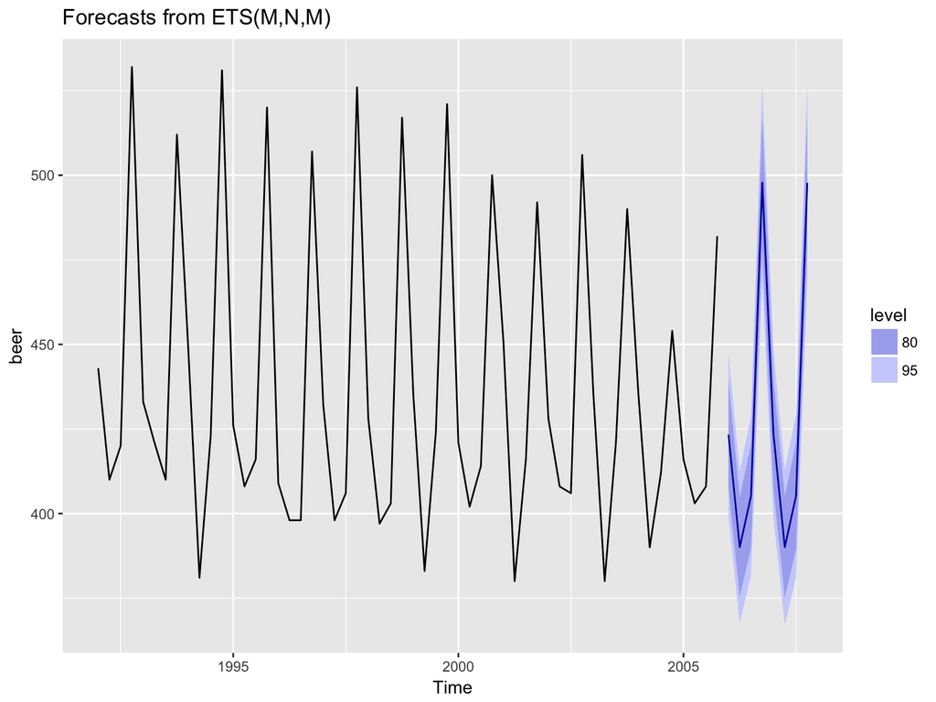

```r
beer <-  window(ausbeer, start = 1992, end = c(2005,4))
beer.ets <- ets(beer)
autoplot(forecast(beer.ets))
```

# Some simple forecasting methods

1. Average method: forecast of all future values is equal to mean of historical data.
2. Naïve method: forecasts equal to last observed value.
3. Seasonal naïve method: forecasts equal to last value from same season.

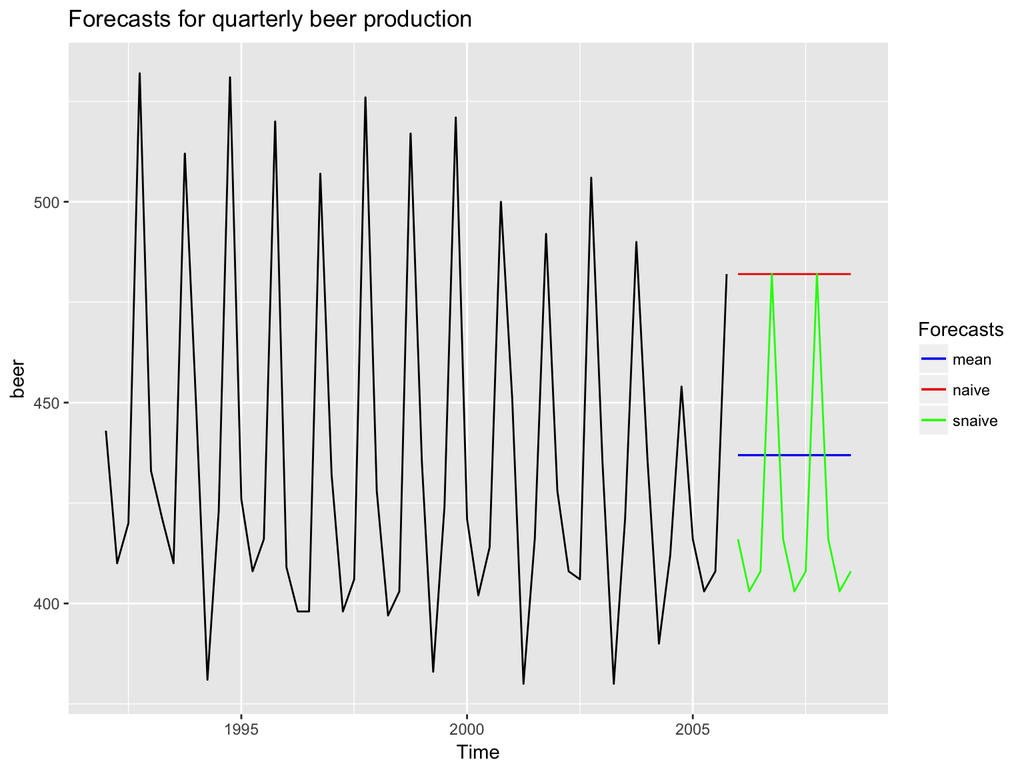

```r
# average method
beerfit.mean <- meanf(beer, h = 11)

# naive method
beerfit.naive <- naive(beer, h = 11)

# seasonal naive method
beerfit.snaive <- snaive(beer, h = 11)

cols <- c("mean" = "#0000ee","naive" = "#ee0000","snaive" = "green")

# plot
autoplot(beerfit.mean, PI = FALSE, main ='Forecasts for quarterly beer production') +
  geom_line(aes(x=time(beerfit.mean$mean),y=beerfit.mean$mean,colour='mean')) +
  geom_line(aes(x=time(beerfit.naive$mean),y=beerfit.naive$mean,colour='naive')) +
  geom_line(aes(x=time(beerfit.snaive$mean),y=beerfit.snaive$mean,colour='snaive')) +
  guides(fill=FALSE) +
  scale_colour_manual(name="Forecasts",values=cols)
```

# Check residuals

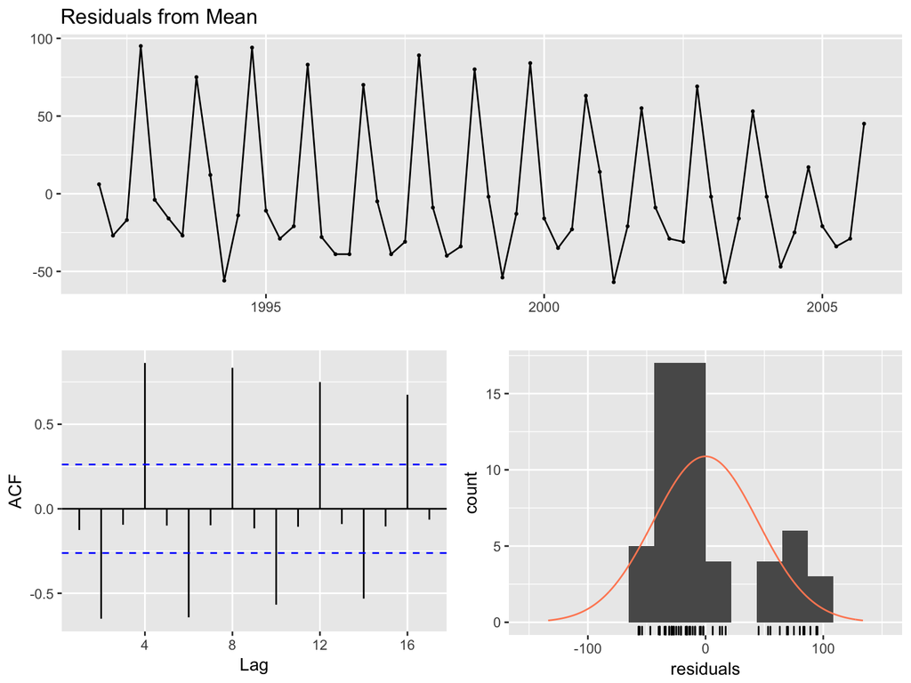

```
##
##  Ljung-Box test
##
## data:  residuals
## Q* = 148.53, df = 7, p-value < 2.2e-16
##
## Model df: 1.   Total lags used: 8
```

```r
# check whether the residuals are random
checkresiduals(beerfit.mean)
```

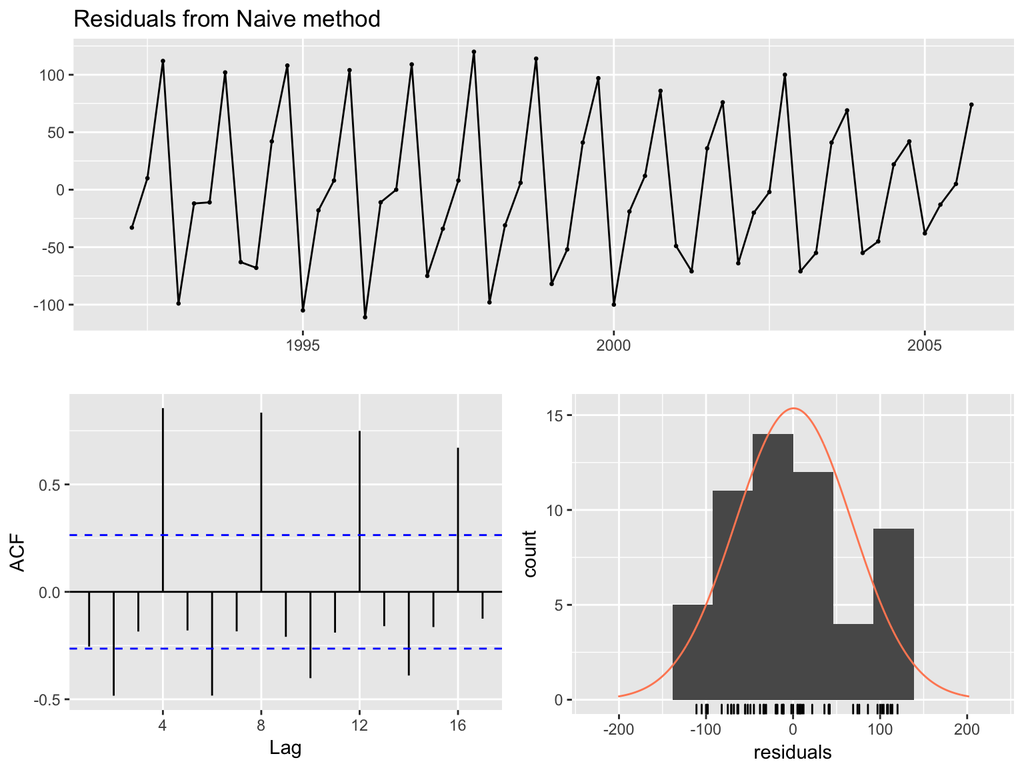

```
##
##  Ljung-Box test
##
## data:  residuals
## Q* = 130.18, df = 8, p-value < 2.2e-16
##
## Model df: 0.   Total lags used: 8
```

```r
checkresiduals(beerfit.naive)
```

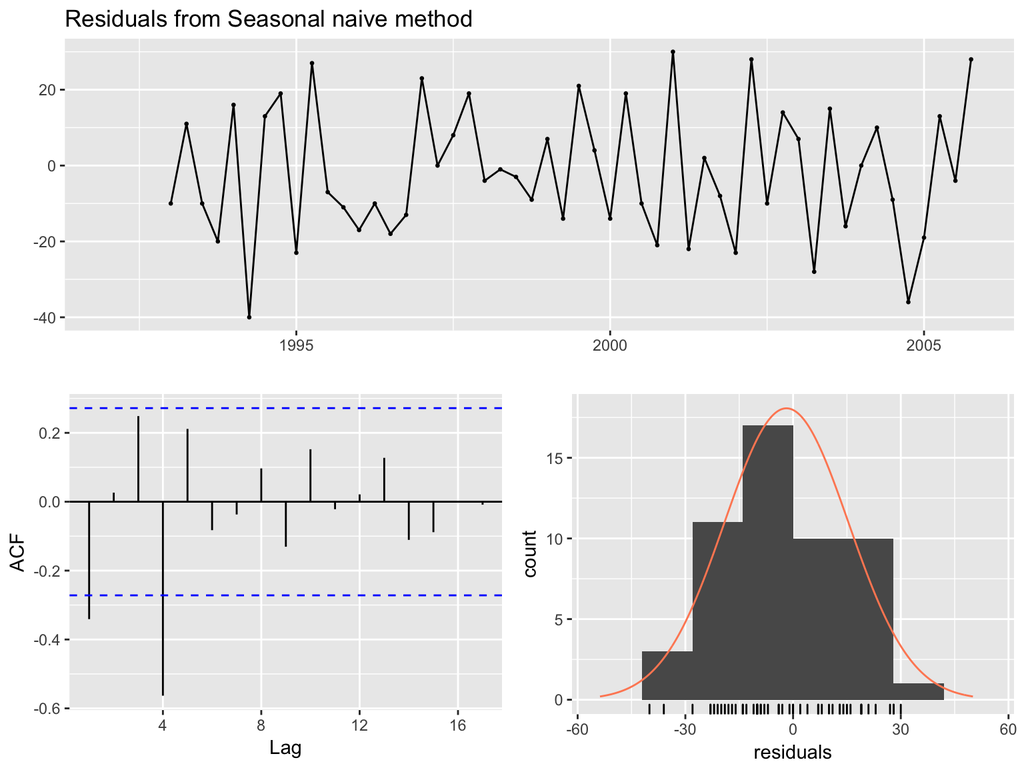

```
##
##  Ljung-Box test
##
## data:  residuals
## Q* = 32.302, df = 8, p-value = 8.224e-05
##
## Model df: 0.   Total lags used: 8
```

```r
checkresiduals(beerfit.snaive)
```

# Measures of forecast accuracy

```r
# check accuracy of forecasting
beer2 <- window(ausbeer, start=2006)
accuracy(beerfit.mean, beer2)
```

```
##                         ME     RMSE      MAE        MPE     MAPE     MASE
## Training set  8.121418e-15 44.17630 35.91135 -0.9510944 7.995509 2.444228
## Test set     -1.718344e+01 38.01454 33.77760 -4.7345524 8.169955 2.298999
##                     ACF1 Theil's U
## Training set -0.12566970        NA
## Test set     -0.08286364 0.7901651
```

```r
accuracy(beerfit.naive, beer2)
```

```
##                       ME     RMSE      MAE         MPE     MAPE     MASE
## Training set   0.7090909 66.60207 55.43636  -0.8987351 12.26632 3.773156
## Test set     -62.2727273 70.90647 63.90909 -15.5431822 15.87645 4.349833
##                     ACF1 Theil's U
## Training set -0.25475212        NA
## Test set     -0.08286364  1.428524
```

```r
accuracy(beerfit.snaive, beer2)
```

```
##                     ME     RMSE      MAE        MPE     MAPE      MASE
## Training set -1.846154 17.24261 14.69231 -0.4803931 3.401224 1.0000000
## Test set     -2.545455 12.96849 11.27273 -0.7530978 2.729847 0.7672537
##                    ACF1 Theil's U
## Training set -0.3408329        NA
## Test set     -0.1786912   0.22573
```

Trend and Seasonality

# Time series components

1. Trend: pattern exists when there is a long-term increase or decrease in the data.
2. Seasonal: pattern exists when a series is influenced by seasonal factors (e.g., the quarter of the year, the month, or day of the week).
3. Cyclic: pattern exists when data exhibit rises and falls that are not of fixed period (duration usually of at least 2 years).

# Time series decomposition

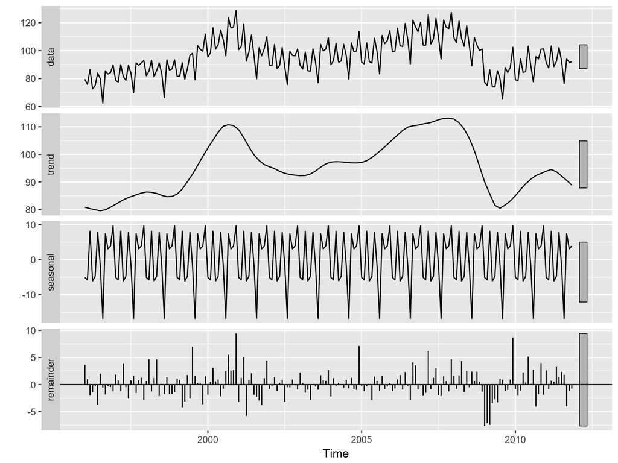

```r
fit <- stl(elecequip, t.window=15, s.window="periodic", robust=TRUE)
autoplot(fit)
```

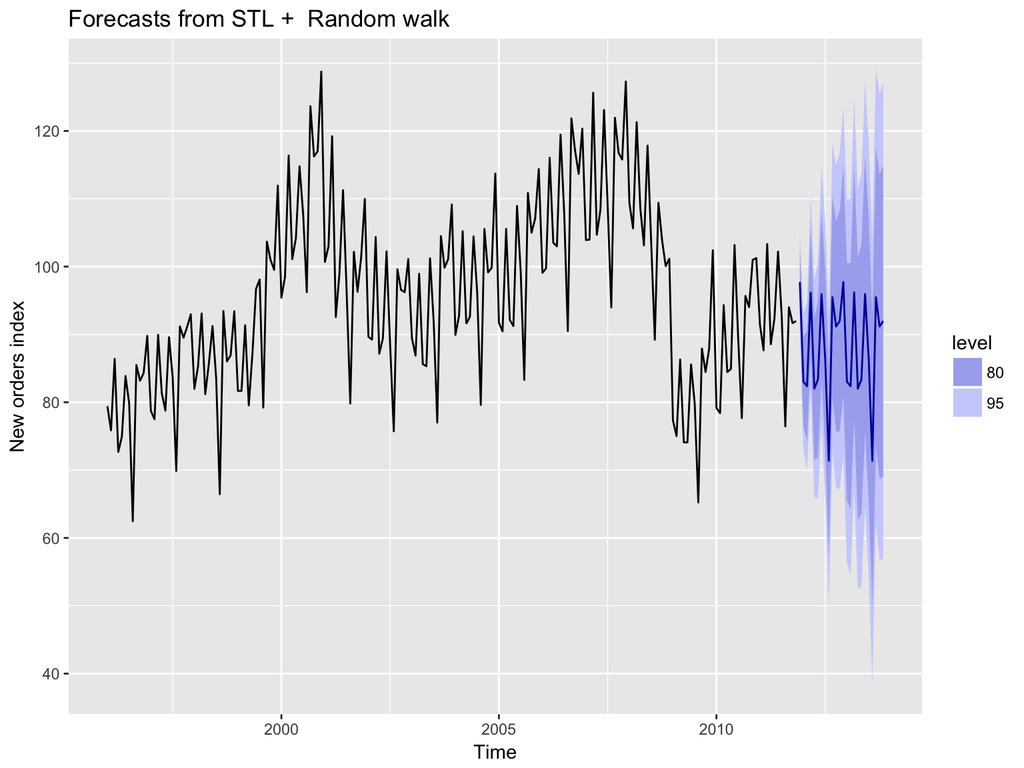

```r
fcast <- forecast(fit, method="naive", h=24)
autoplot(fcast) + ylab("New orders index")
```

ARIMA models

# ARIMA models

#### ARMA models

$y_t = c + \phi_1 y_{t-1} + \cdots + \phi_p y_{t-p} + \theta_1 e_{t-1} + \cdots + \theta_1 e_{t-q}$

#### ARIMA models

$(1-B)^dy_t$ follows an ARMA model.

# ARIMA forecasting

#### Nonseasonal

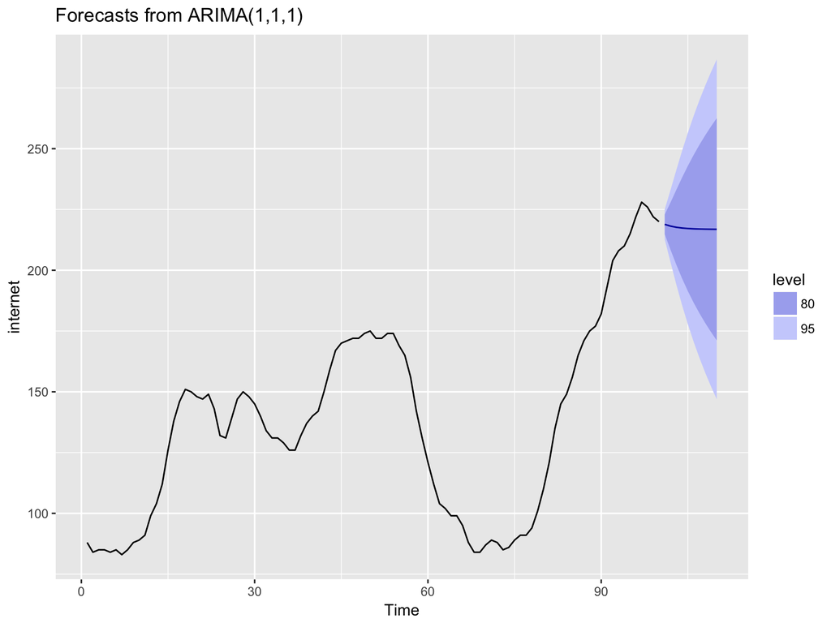

```r
fit <- auto.arima(internet)
autoplot(forecast(fit))
```

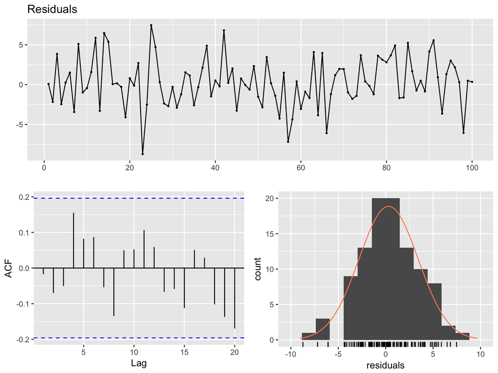

```
##
##  Ljung-Box test
##
## data:  residuals
## Q* = 7.8338, df = 8, p-value = 0.4499
##
## Model df: 2.   Total lags used: 10
```

```r
checkresiduals(fit)
```

#### Seasonal

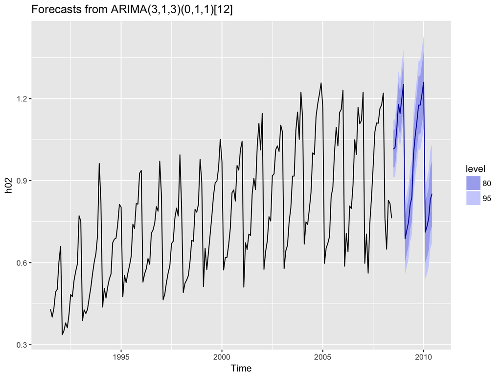

```r
fit <- auto.arima(h02)
autoplot(forecast(fit))
```

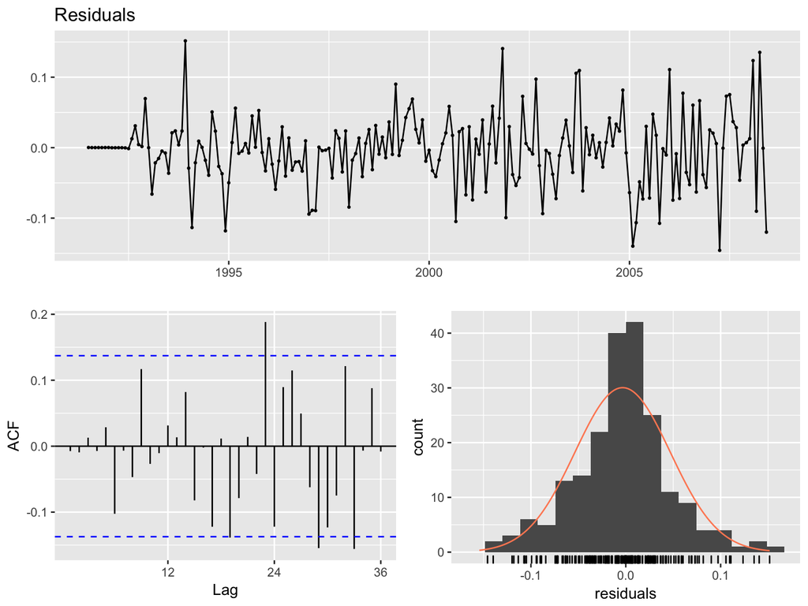

```
##
##  Ljung-Box test
##
## data:  residuals
## Q* = 30.66, df = 17, p-value = 0.02196
##
## Model df: 7.   Total lags used: 24
```

```r
checkresiduals(fit)
```

# References

[figure not shown]